# Simple Linear Regression Analysis

PHILHOON OH

October 5, 2016

# Abstract

In this report, I will reproduce the main results displayed in section 3.1 *Simple Linear Regression* (chapter3) of the book **An introduction to Statistical Learning.**

# Introduction

The overall goal is to provide advice on how to improve sales of the particular product. More specifically, the idea is to determine whether there is an association between advertising and sales, and if so, develop an accurate model that can be used to predict sales on the basis of the three media budgets

# Data

The Advertising data set consists of the Sales (in thousands of units) of a particular product in 200 different markets, along with advertising budgets (in thousands of dollars) for the product in each of those markets for three different media: TV, Radio, and Newspaper.

# Methodology

We consider one media from the data set, TV, and study its relationship with Sales. For this purpose, we use a simple linear model:

$$\\Sales = \beta_{0} + \beta_{1}TV$$

To estimate the coefficients $\beta_{0}$ and $\beta_{1}$ we fit a regression model via the least squares criterion.

# Results

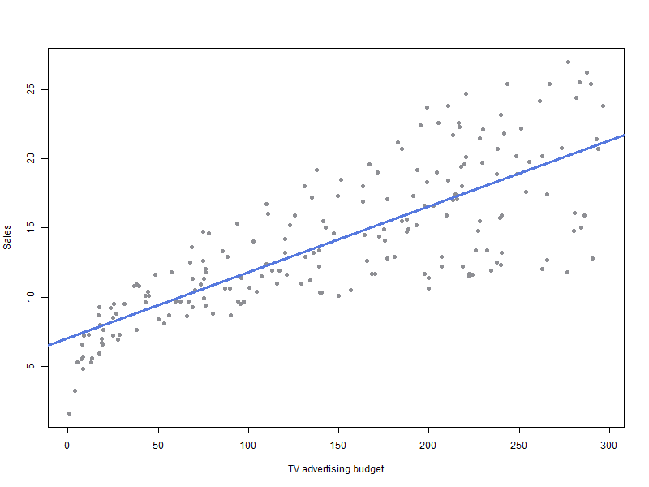

scatterplot-tv-sales